# Exercice 4

## Partie 1 : Simulation

Les données pour cet exercice sont stockées dans le fichier `RM04data.csv`. Commençons par charger ces données.

```r
# La fonction read_csv2 est issue du package readr qui permet des imports
# exports facilités dans R
df <- read.csv("../data/RM04data.csv", sep = ',', header = FALSE)
df <- df[1:4,]

columns_names = c("xi_sys1", "xi_sys2", "xi_sys3", "xi_sys4")
observations_labels <- paste('x',as.character(1:200),sep = '')

rownames(df) <- columns_names
colnames(df) <- observations_labels

df <- t(df)

head(df)
```

```
##      xi_sys1  xi_sys2   xi_sys3   xi_sys4
## x1 2.9304179 4.677403 2.2591062 2.9184215
## x2 6.4750017 7.326121 4.9916828 4.2306659
## x3 1.3918117 3.717424 1.0729700 0.2696511
## x4 4.1970742 4.407853 3.2355919 2.8474980
## x5 6.9849789 3.184897 3.6016684 0.0614171
## x6 0.4195876 3.162764 0.3234668 0.6936315
```

Pour vérifier :

```r
dim(df)
```

```
## [1] 200   4
```

On a donc un jeu de données à 4 échantillons de 200 éléments (les temps d’observation inter-pannes $x_i$).

L’objectif de cet exercice est d’identifier les lois les plus adaptées à chaque échantillon.

On peut commencer à travailler les données en calculant les $T_i$ : les dates de panne observées.

```r
df <- cbind(df,cumsum(df[,1]),cumsum(df[,2]),cumsum(df[,3]),cumsum(df[,4]))
columns_names <- c(columns_names,
                   "ti_sys1", "ti_sys2", "ti_sys3", "ti_sys4")

colnames(df) <- columns_names

head(df)
```

```
##      xi_sys1  xi_sys2   xi_sys3   xi_sys4   ti_sys1   ti_sys2   ti_sys3
## x1 2.9304179 4.677403 2.2591062 2.9184215  2.930418  4.677403  2.259106
## x2 6.4750017 7.326121 4.9916828 4.2306659  9.405420 12.003525  7.250789
## x3 1.3918117 3.717424 1.0729700 0.2696511 10.797231 15.720948  8.323759
## x4 4.1970742 4.407853 3.2355919 2.8474980 14.994306 20.128801 11.559351
## x5 6.9849789 3.184897 3.6016684 0.0614171 21.979284 23.313698 15.161019
## x6 0.4195876 3.162764 0.3234668 0.6936315 22.398872 26.476462 15.484486
##      ti_sys4
## x1  2.918421
## x2  7.149087
## x3  7.418738
## x4 10.266236
## x5 10.327654
## x6 11.021285
```

On obtient les $T_i$ en faisant la somme cumulée des $x_i$ ce qui donne :

$$\forall i \in [1,n] : T_i = \sum_{k=1}^{i} x_k$$

### Échantillon n°1

On peut commencer par tracer les données :

- l’évolution des durées inter-pannes,
- les dates de panne.

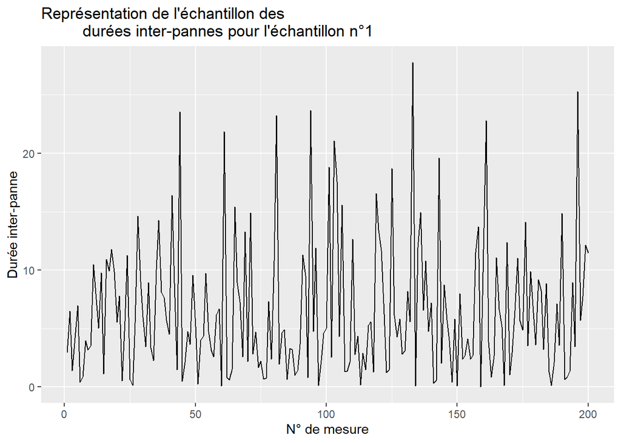

```r
ggplot() +
    geom_line(aes(x = 1:200, y = df[,"xi_sys1"])) +
    labs(x = "N° de mesure",
         y = "Durée inter-panne",
         title = "Représentation de l'échantillon des
         durées inter-pannes pour l'échantillon n°1")
```

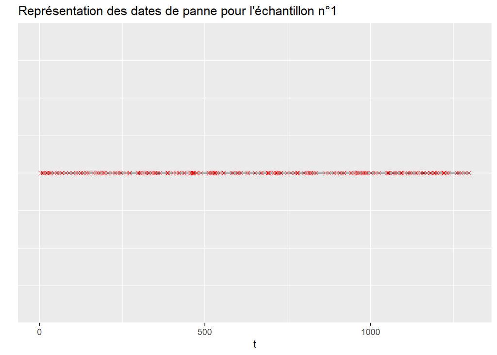

```r
ggplot() +
    geom_line(aes(x = 1:1300, y = 1)) +
    geom_point(aes(x = df[,"ti_sys1"], y = 1)
               , color = "red",
               shape = 4) +
    labs(x = "t",
         y = "",
         title = "Représentation des dates de panne pour l'échantillon n°1") +
    guides(y = "none")
```

D’après les deux graphiques précédent, on peut supposer que la variable aléatoire dont est issue l’échantillon n°1 ne présente pas de tendance : il semble que les dates de pannes (et donc les durées inter-pannes) sont uniformément distribuées.

#### Tendance

Si les $X_i$ (ou $T_i$) sont $iid$, l’échantillon ne possède aucune tendance. On va donc tester l’hypothèse selon laquelle notre échantillon est $iid$ pour déterminer ou non la présence de tendance.

Nous disposons de deux outils mathématique :

- le test de Laplace,
- le test de Spearman.

Je propose d’utiliser le test de Laplace dans un premier temps.

Dans le cadre de la sûreté de fonctionnement il se présente ainsi :

$$\left\{
\begin{array}{ll}
H_0 : \mbox{les données sont issues d'un processus de poisson
homogène} \\
H_1 : \mbox{les données ne sont pas issues d'un processus de
poisson homogène}
\end{array}
\right.$$

Si l’on établit que les données sont issues d’un processus de Poisson Homogène (PPH), alors par définition, on établit que les données ne possèdent pas de tendance.

On a la statistique de test suivante :

$$U =
\sqrt{\frac{12}{(n-1)T_n^2}}
\left(\sum_{i=1}^{n} T_i - (n+1)\frac{T_n}{2} \right)$$
que l’on compare à au quantile de la loi normale centrée réduite.

$$\left\{
\begin{array}{ll}
|U| > F_{N_{(0,1)}}^{-1} (1-\frac{\alpha}{2})\mbox{, alors on
rejette } H_0\\
|U| < F_{N_{(0,1)}}^{-1} (1-\frac{\alpha}{2}) \mbox{, on ne
rejette pas } H_0
\end{array}
\right.$$

Si on conserve $H_0$ on en conclue que l’échantillon est issus d’un PPH, et donc qu’il n’y a pas de tendance.

On peut écrire une fonction qui calcule la statistique de test en fonction des $T_i$:

```r
compute_laplace_stat <- function(ti){

  # Prend le tableau des Ti en entrée de fonction et retourne U

  n <- length(ti)
  U <- sqrt((12)/((n-1)*ti[n]^2))*(sum(ti)-(n+1)*ti[n]/2)

  U %>% as.numeric %>% return()

}
```

On calcul la statistique de test $U$ :

```r
compute_laplace_stat(df[,"ti_sys1"])
```

```
## [1] -0.5647952
```

Au seuil $\alpha = 0.05$ on va comparer la statistique de test avec le quantile de la loi normale centrée réduite de $1.96$.

```r
alpha = 0.05 # risque
n = 200 # nombre d'observartion
qnorm(1-alpha/2)
```

```
## [1] 1.959964
```

On a bel et bien $|U| < 1.96$, on ne rejette donc pas $H_0$ et on peut conclure que la série de mesure ne possède pas de tendance.

#### Adéquation à la loi exponentielle

Le test précédent nous confirme qu’il n’y a pas de tendance.

On peut alors tester l’adéquation des données avec une loi exponentielle.

On peut utiliser un test de Bartlett que l’on doit programmer.

Le test se présente ainsi :

$$\left\{
\begin{array}{ll}
H_0 : \mbox{les données sont issues d'un processus de poisson
homogène} \\
H_1 : \mbox{les données ne sont pas issues d'un processus de
poisson homogène}
\end{array}
\right.$$

Avec la statistique de test :

$$B = \frac{2n\left( ln\left(\frac{T_n}{n}\right)
- \frac{\sum_{i=1}^{n}ln(X_i)}{n}
\right)}
{1+\frac{n+1}{6n}}$$

que l’on compare au quantile de la loi du $\chi^2_{n-1}$

$$\left\{
\begin{array}{ll}
B \in \left[ F_{\chi_{n-1}^2}^{-1}(\frac{\alpha}{2}) ;
F_{\chi_{n-1}^2}^{-1}(1-\frac{\alpha}{2}) \right]
\mbox{, on ne rejette pas } H_0 \\
B \notin \left[ F_{\chi_{n-1}^2}^{-1}(\frac{\alpha}{2}) ;
F_{\chi_{n-1}^2}^{-1}(1-\frac{\alpha}{2}) \right]
\mbox{, alors on rejette } H_0
\end{array}
\right.$$

```r
compute_bartlett_stat <- function(tn, xi) {

  n <- length(xi)

  2*n*(log(tn/n)-sum(log(xi))/n)/(1+((n+1)/(6*n))) %>% return()
}
```

```r
# on calcule la statistique de test
compute_bartlett_stat(df[n,"ti_sys1"], df[,"xi_sys1"])
```

```
## [1] 183.6263
```

On cherche alors le quantile de la loi du $\chi^2$ :

```r
qchisq(p = 0.025, n-1)
```

```
## [1] 161.8262
```

```r
qchisq(p = 0.975, n-1)
```

```
## [1] 239.9597
```

Dans ce cas on ne va pas rejeter $H_0$ et considérer que l’échantillon est issu d’un processus de poisson homogène (PPH).

Les observations sont donc issus d’une variable aléatoire exponentielle.

On peut compléter l’analyse avec une adéquation graphique.

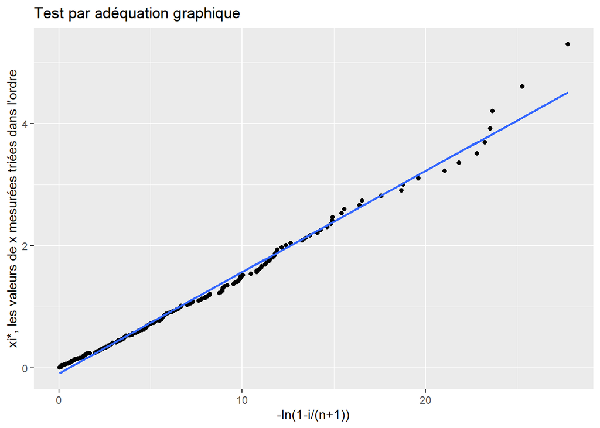

```r
nuage = tibble(-log(1-(1:200)/(n+1)),sort(df[,"xi_sys1"]))
colnames(nuage) <- c('formula','x')

ggplot() +
    geom_point(aes(x = nuage$`x`,y = nuage$formula)) +
    geom_smooth(aes(x = nuage$`x`,y = nuage$formula),
                se = FALSE,
                method = lm) +
    labs(y = "xi*, les valeurs de x mesurées triées dans l'ordre",
         x = "-ln(1-i/(n+1))",
         title = "Test par adéquation graphique")
```

La fonction `geom_smooth` du package `ggplot2` permet d’ajuster une droite de régression aux données affichées.

On peut utiliser la fonction `lm` pour obtenir les informations sur la droite de régression.

```r
lm(nuage$formula~nuage$x) %>% summary()
```

```
##
## Call:
## lm(formula = nuage$formula ~ nuage$x)
##
## Residuals:
##      Min       1Q   Median       3Q      Max
## -0.17956 -0.04031 -0.01285  0.04897  0.79090
##
## Coefficients:
##              Estimate Std. Error t value Pr(>|t|)
## (Intercept) -0.086328   0.010183  -8.478 5.24e-15 ***
## nuage$x      0.165511   0.001177 140.603  < 2e-16 ***
## ---
## Signif. codes:  0 '***' 0.001 '**' 0.01 '*' 0.05 '.' 0.1 ' ' 1
##
## Residual standard error: 0.09529 on 198 degrees of freedom
## Multiple R-squared:  0.9901, Adjusted R-squared:   0.99
## F-statistic: 1.977e+04 on 1 and 198 DF,  p-value: < 2.2e-16
```

La valeur de la pente de la droite de régression estimée par la fonction `lm` est de $0.165511$, il s’agit d’une estimation de $\lambda$ que l’on notera $\hat{\lambda}_{gph}^{sys1}$

On a un $R^2=0.99$ ce qui permet de renforcer la conclusion selon laquelle l’échantillon est issue d’une loi exponentielle.

#### Estimation des paramètres

On peut ensuite chercher à estimer les paramètres

```r
estim_param_sys1_mm = 1/mean(df[,"xi_sys1"])
estim_param_sys1_mm
```

```
## [1] 0.1541832
```

On trouve donc l’estimateur par méthode des moments : $\hat{\lambda}_{mm}^{sys_{1}} \simeq 0.1541832$.

Nos deux estimateurs : $\hat{\lambda}_{mm}^{sys_{1}} \simeq 0.1541832$ et $\hat{\lambda}_{gph}^{sys1} \simeq 0.165511$ sont très proches quoi que légèrement différents.

#### Représentation graphique des deux modèles

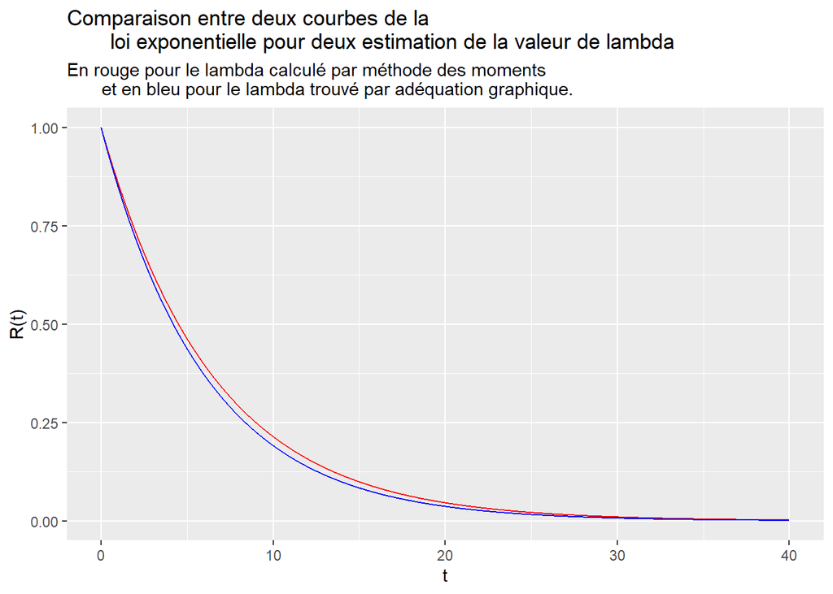

```r
estim_param_sys1_gph = 0.165511
t = seq(0,40,0.001)

ggplot() +
  geom_line(aes(t, 1-pexp(t,estim_param_sys1_mm)), color = 'red') +
  geom_line(aes(t, 1-pexp(t,estim_param_sys1_gph)), color = 'blue') +
  xlim(0,40) +
  ylim(0,1) +
  labs(x = "t",
       y = "R(t)",
       title = "Comparaison entre deux courbes de la
       loi exponentielle pour deux estimation de la valeur de lambda",
       subtitle = "En rouge pour le lambda calculé par méthode des moments
       et en bleu pour le lambda trouvé par adéquation graphique.")
```

On remarque que la courbe rouge semple mieux correspondre aux données.

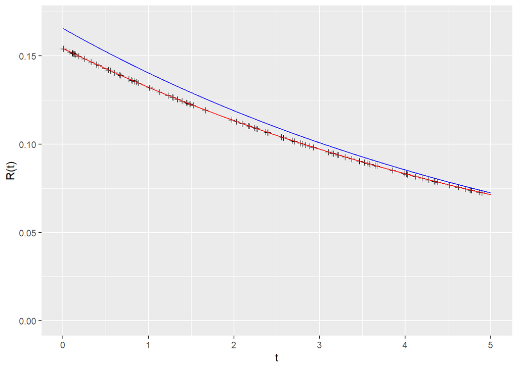

```r
ggplot() +
  geom_point(aes(
      x = df[,"xi_sys1"],
      y = estim_param_sys1_mm*exp(-1*estim_param_sys1_mm*df[,"xi_sys1"])
    ),
    shape = 3,
    color = 'black') +
  geom_line(aes(t, dexp(t,estim_param_sys1_mm)), color = 'red') +
  geom_line(aes(t, dexp(t,estim_param_sys1_gph)), color = 'blue') +
  xlim(0,5) +
  ylim(0,0.17) +
  labs(x = "t",
       y = "R(t)")
```

#### Conclusion

On peut donc conclure que l’échantillon n°1 est issue d’un système suivant une loi exponentielle de paramètre $\lambda = 0.1541832$ donc de moyenne (nous de disposons pas des unités) :

```r
1/estim_param_sys1_mm
```

```
## [1] 6.48579
```

### Échantillon n°2

On commence par tracer l’échantillon :

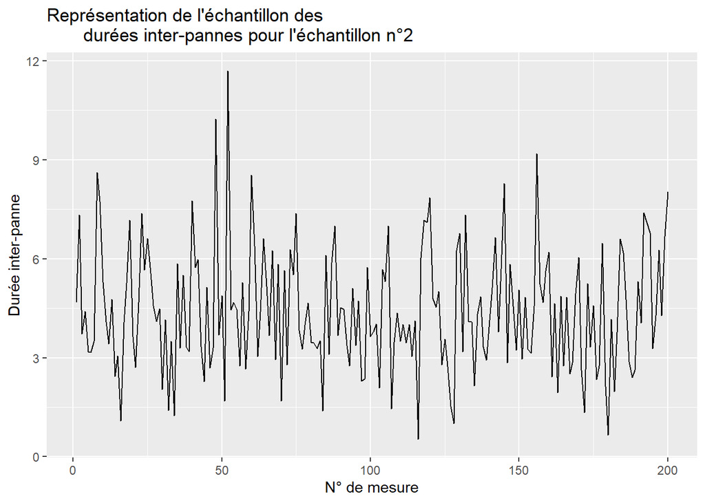

```r
ggplot() +
  geom_line(aes(x = 1:200, y = df[,"xi_sys2"])) +
  labs(x = "N° de mesure",
       y = "Durée inter-panne",
       title = "Représentation de l'échantillon des
       durées inter-pannes pour l'échantillon n°2")
```

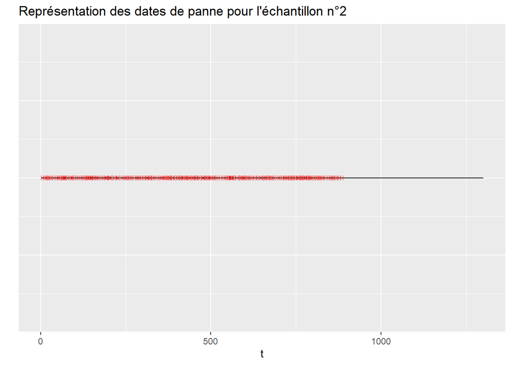

```r
ggplot() +
  geom_line(aes(x = 1:1300, y = 1)) +
  geom_point(aes(x = df[,"ti_sys2"], y = 1)
             , color = "red",
             shape = 4) +
  labs(x = "t",
       y = "",
       title = "Représentation des dates de panne pour l'échantillon n°2") +
  guides(y = "none")
```

On peut encore supposer une absence de tendance au vu de la répartition des pannes.

#### Tendance

Pour observer la tendance on peut utiliser le test de Laplace.

```r
compute_laplace_stat(df[,"ti_sys2"])
```

```
## [1] 0.1656895
```

Là encore, on est en dessous de 1.96, on peut conclure à l’absence de tendance.

#### Adéquation à la loi exponentielle

On réalise un test de Bartlett :

```r
compute_bartlett_stat(df[200,"ti_sys2"], df[,"xi_sys2"])
```

```
## [1] 33.92903
```

Dans ce cas on va très clairement rejeter $H_0$ car nous ne nous trouvons pas entre les quantiles du $\chi^2$ :

```r
qchisq(p = 0.025, n-1)
```

```
## [1] 161.8262
```

```r
qchisq(p = 0.975, n-1)
```

```
## [1] 239.9597
```

Donc la loi exponentielle ne semble pas adéquate à cet échantillon.

#### Adéquation à la loi de Weibull par maintenance parfaite

On peut alors tester l’hypothèse selon laquelle la variable aléatoire dont l’échantillon est issue suit une loi de Weibull avec réparation parfaite.

On peut vérifier cette hypothèse en par adéquation graphique.

Pour celà on doit tracer le nuage de point :

$$\left( ln(x_i^*),
ln \left(ln \left( \frac{1}{1-\frac{i}{n+1}} \right) \right) \right)$$

Avec les $x_i^*$ sont les données mesurées triées dans l’ordre.

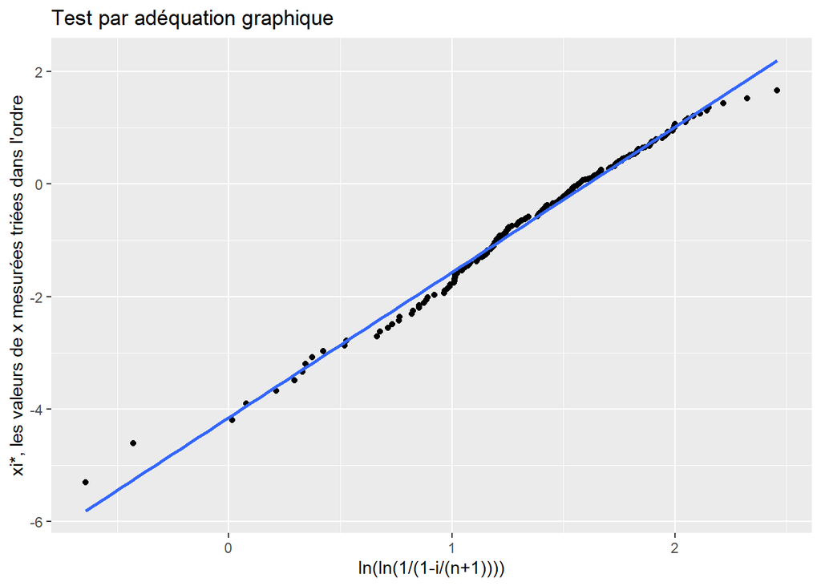

```r
nuage2 = tibble(log(log(1/(1-((1:200)/(n+1))))),log(sort(df[,"xi_sys2"])))
colnames(nuage2) <- c('formula','x')

ggplot() +
    geom_point(aes(x = nuage2$`x`,y = nuage2$formula)) +
    geom_smooth(aes(x = nuage2$`x`,y = nuage2$formula),
                se = FALSE,
                method = lm) +
    labs(y = "xi*, les valeurs de x mesurées triées dans l'ordre",
         x = "ln(ln(1/(1-i/(n+1))))",
         title = "Test par adéquation graphique")
```

Par adéquation graphique on trouve une très bonne droite.

On peut effectuer la régression pour conclure sur l’adéquation.

```r
lm(nuage2$formula~nuage2$x) %>% summary()
```

```
##
## Call:
## lm(formula = nuage2$formula ~ nuage2$x)
##
## Residuals:
##      Min       1Q   Median       3Q      Max
## -0.53439 -0.04541  0.02479  0.07192  0.65719
##
## Coefficients:
##             Estimate Std. Error t value Pr(>|t|)
## (Intercept) -4.15267    0.02674  -155.3   <2e-16 ***
## nuage2$x     2.58428    0.01823   141.8   <2e-16 ***
## ---
## Signif. codes:  0 '***' 0.001 '**' 0.01 '*' 0.05 '.' 0.1 ' ' 1
##
## Residual standard error: 0.1227 on 198 degrees of freedom
## Multiple R-squared:  0.9902, Adjusted R-squared:  0.9902
## F-statistic: 2.01e+04 on 1 and 198 DF,  p-value: < 2.2e-16
```

Avec une $p_{value}=2.2e-16$ et un $R^2=0.9902$ on conclure à la pertinence d’effectuer une droite de regression sur ces données.

On peut effectuer deux estimations des paramètres.

#### Estimation des paramètres

Graphiquement on a :
$$\mbox{Pente de la droite de regression} = \hat{\beta}_{gph} \\
\mbox{Ordonnée à l'origine} = -\hat{\beta}_{gph}
ln(\hat{\theta}_{gph})\\
\hat{\theta}_{gph} = e^{-\frac{OaO}{\hat{\beta}_{gph}}}$$

Donc on a :

```r
beta = 2.58428
theta = exp(-(-4.15267)/(beta))
estim_param_sys2_gph = list(beta = beta, theta = theta)
print(estim_param_sys2_gph)
```

```
## $beta
## [1] 2.58428
##
## $theta
## [1] 4.987308
```

Par estimation par maximum de vraisemblance :

```r
# Focntion du package EWGoF
estim_param_sys2_mv <- MLEst(df[,"xi_sys2"])
estim_param_sys2_mv$eta
```

```
## [1] 4.980278
```

```r
estim_param_sys2_mv$beta
```

```
## [1] 2.535939
```

Les deux estimations sont très proches.

#### Représentation graphique des deux modèles

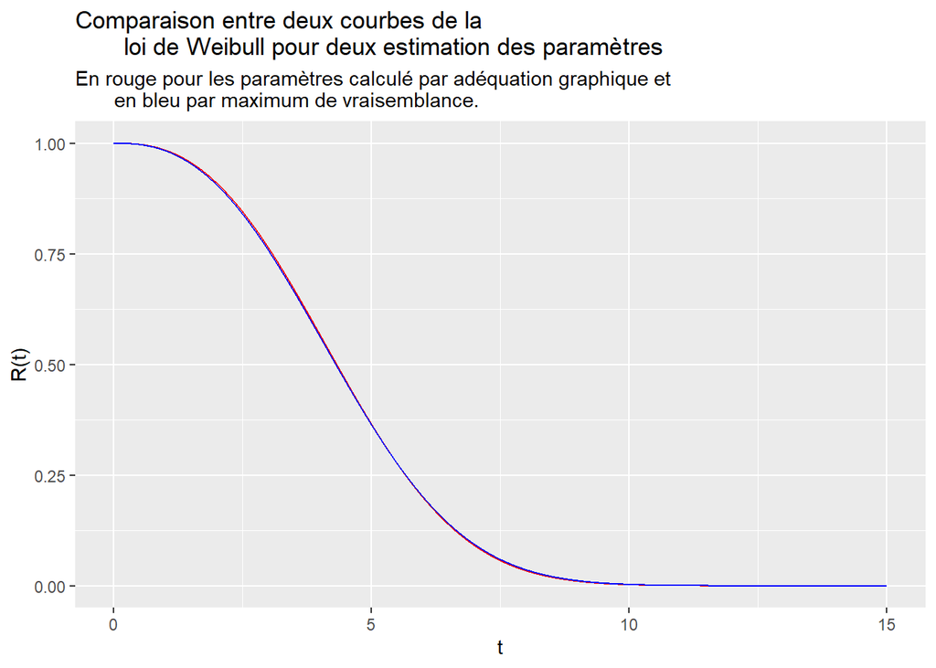

```r
t = seq(0,15,0.001)
ggplot() +
  geom_line(
    aes(t, 1-pweibull(t,
                    shape = estim_param_sys2_gph$beta,
                    scale = estim_param_sys2_gph$theta)),
    color = 'red') +
  geom_line(
    aes(t, 1-pweibull(t,
                    shape = estim_param_sys2_mv$beta,
                    scale = estim_param_sys2_mv$eta)),
    color = 'blue') +
  labs(x = "t",
       y = "R(t)",
       title = "Comparaison entre deux courbes de la
       loi de Weibull pour deux estimation des paramètres",
       subtitle = "En rouge pour les paramètres calculé par adéquation graphique et
       en bleu par maximum de vraisemblance.")
```

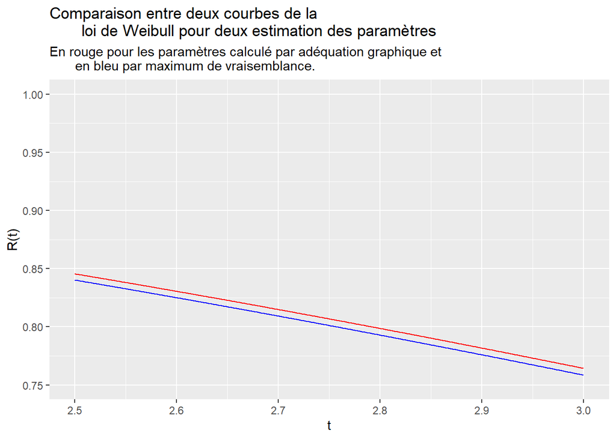

```r
t = seq(0,15,0.001)
ggplot() +
  geom_line(
    aes(t, 1-pweibull(t,
                    shape = estim_param_sys2_gph$beta,
                    scale = estim_param_sys2_gph$theta)),
    color = 'red') +
  geom_line(
    aes(t, 1-pweibull(t,
                    shape = estim_param_sys2_mv$beta,
                    scale = estim_param_sys2_mv$eta)),
    color = 'blue') +
  labs(x = "t",
       y = "R(t)",
       title = "Comparaison entre deux courbes de la
       loi de Weibull pour deux estimation des paramètres",
       subtitle = "En rouge pour les paramètres calculé par adéquation graphique et
       en bleu par maximum de vraisemblance.") +
  xlim(2.5,3) +
  ylim(0.75,1)
```

Les deux solutions offrent des résultats similaires, la différence est au centième.

#### Conclusion

l’échantillon n°2 est issue d’une variable aléatoire suivant une loi de Weibull. Nous disposons de deux estimations de paramètres :

- $\beta = 2.58428$ et $\theta = 4.987308$ pour adéquation graphique.
- $\beta = 2.535939$ et $\theta = 4.980278$ par estimation du maximum de vraisemblance.

On ne peut pas trancher simplement en effectuant une moyenne des deux paramètres. On peut choisir l’une ou l’autre ou procéder à d’avantage d’analyses.

Je propose de conserver l’estimation par maximum de vraisemblance (la lecture graphique induit une erreur supplémentaire lors de la régression).

Dans ce cas on a : $MMTF_{sys_{2}} = \theta \Gamma(1+\frac{1}{\beta})$

La fonction `gamma()` de R permet de calculer $\Gamma(x)$.

```r
print("MTTF pour le système 2 :")
```

```
## [1] "MTTF pour le système 2 :"
```

```r
estim_param_sys2_mv$eta*gamma(1+1/estim_param_sys2_mv$beta)
```

```
## [1] 4.420431
```

### Échantillon n°3

On peut commencer par tracer les données :

- l’évolution des durées inter-pannes,
- les dates de panne.

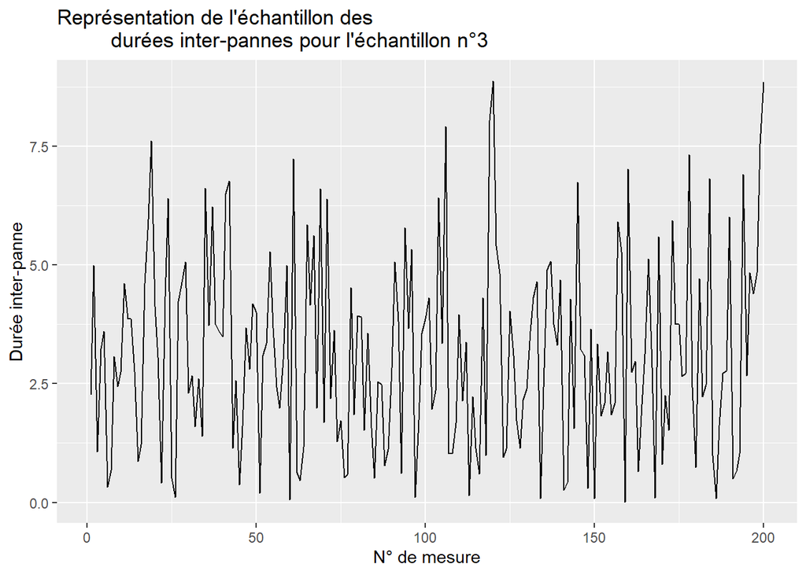

```r
ggplot() +
    geom_line(aes(x = 1:200, y = df[,"xi_sys3"])) +
    labs(x = "N° de mesure",
         y = "Durée inter-panne",
         title = "Représentation de l'échantillon des
         durées inter-pannes pour l'échantillon n°3")
```

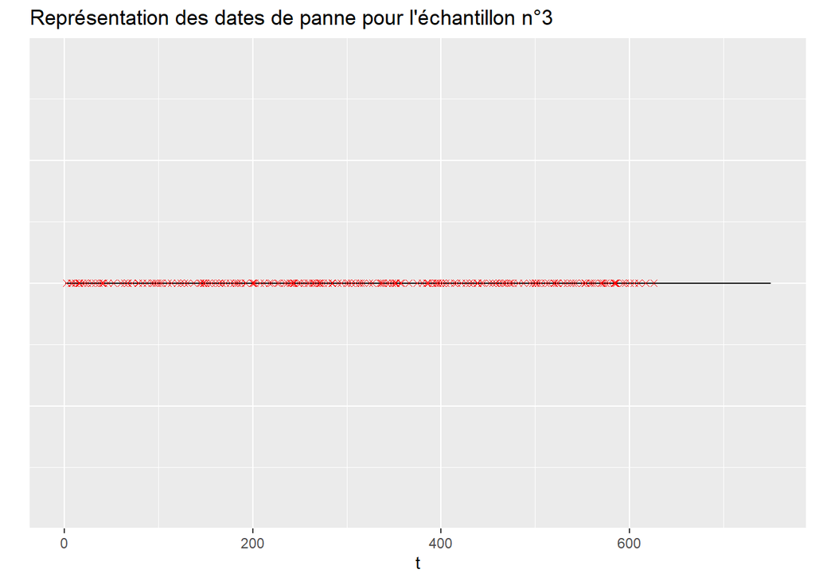

```r
ggplot() +
    geom_line(aes(x = 1:750, y = 1)) +
    geom_point(aes(x = df[,"ti_sys3"], y = 1)
               , color = "red",
               shape = 4) +
    labs(x = "t",
         y = "",
         title = "Représentation des dates de panne pour l'échantillon n°3") +
    guides(y = "none")
```

A première vue il n’y a pas de tendance dans le jeu de données.

#### Tendance

Pour observer la tendance on peut utiliser le test de Laplace.

```r
compute_laplace_stat(df[,"ti_sys3"])
```

```
## [1] -0.2057661
```

Là encore, on est en dessous de 1.96, on peut conclure à l’absence de tendance.

#### Adéquation à la loi exponentielle

On réalise un test de Bartlett :

```r
compute_bartlett_stat(df[200,"ti_sys3"], df[,"xi_sys3"])
```

```
## [1] 125.6443
```

Dans ce cas on va rejeter $H_0$ car nous ne nous trouvons pas entre les quantiles du $\chi^2$ :

```r
qchisq(p = 0.025, n-1)
```

```
## [1] 161.8262
```

```r
qchisq(p = 0.975, n-1)
```

```
## [1] 239.9597
```

On conclue donc que la loi exponentielle n’est pas adaptée pour modéliser ces données.

#### Adéquation à la loi de Weibull par maintenance parfaite

On réutilise la même idée que pour le second échantillon : on passe par l’ adéquation graphique.

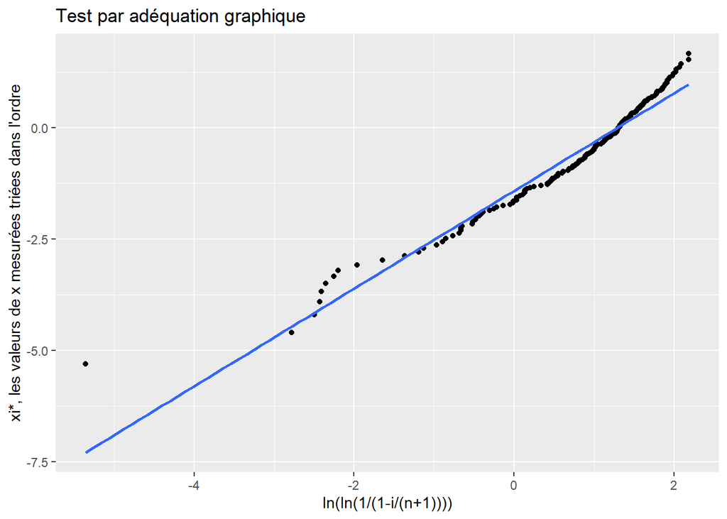

```r
nuage3 = tibble(log(log(1/(1-((1:200)/(n+1))))),log(sort(df[,"xi_sys3"])))
colnames(nuage3) <- c('formula','x')

ggplot() +
    geom_point(aes(x = nuage3$`x`,y = nuage3$formula)) +
    geom_smooth(aes(x = nuage3$`x`,y = nuage3$formula),
                se = FALSE,
                method = lm) +
    labs(y = "xi*, les valeurs de x mesurées triées dans l'ordre",
         x = "ln(ln(1/(1-i/(n+1))))",
         title = "Test par adéquation graphique")
```

La droite ne *fit* pas parfaitement avec les données mais reste plutôt bonne. On peut ajouter la resgression linéaire à l’analyse :

```r
lm(nuage3$formula~nuage3$x) %>% summary()
```

```
##
## Call:
## lm(formula = nuage3$formula ~ nuage3$x)
##
## Residuals:
##     Min      1Q  Median      3Q     Max
## -0.3172 -0.1839 -0.0856  0.1433  1.9889
##
## Coefficients:
##             Estimate Std. Error t value Pr(>|t|)
## (Intercept) -1.41662    0.02293  -61.79   <2e-16 ***
## nuage3$x     1.09692    0.01703   64.39   <2e-16 ***
## ---
## Signif. codes:  0 '***' 0.001 '**' 0.01 '*' 0.05 '.' 0.1 ' ' 1
##
## Residual standard error: 0.2652 on 198 degrees of freedom
## Multiple R-squared:  0.9544, Adjusted R-squared:  0.9542
## F-statistic:  4147 on 1 and 198 DF,  p-value: < 2.2e-16
```

On peut considérer au vu du $R^2$ et de la $p_{value} que la loi de Weibull est adaptée à modéliser ces données.

#### Estimation des paramètres

```r
beta = 1.09692
theta = exp(-(-1.41662)/(beta))
estim_param_sys3_gph = list(beta = beta, theta = theta)
print("Graphiquement")
```

```
## [1] "Graphiquement"
```

```r
print(estim_param_sys3_gph)
```

```
## $beta
## [1] 1.09692
##
## $theta
## [1] 3.638067
```

```r
# Focntion du package EWGoF
print("Maximum de vraissemblance")
```

```
## [1] "Maximum de vraissemblance"
```

```r
estim_param_sys3_mv <- MLEst(df[,"xi_sys3"])
print("beta")
```

```
## [1] "beta"
```

```r
estim_param_sys3_mv$beta
```

```
## [1] 1.410595
```

```r
print("theta")
```

```
## [1] "theta"
```

```r
estim_param_sys3_mv$eta
```

```
## [1] 3.406006
```

Dans ce cas, on a une incohérence entre les deux estimations pour la valeur de $\beta$. Il faut donc rejeter l’hypothèse selon laquelle ces données seraient issues d’une loi de Weibull.

#### Conclusion

Plus d’analyse devraient être menées pour conclure sur ce jeu de données.

### Échantillon n°4

On peut commencer par tracer les données :

- l’évolution des durées inter-pannes,
- les dates de panne.

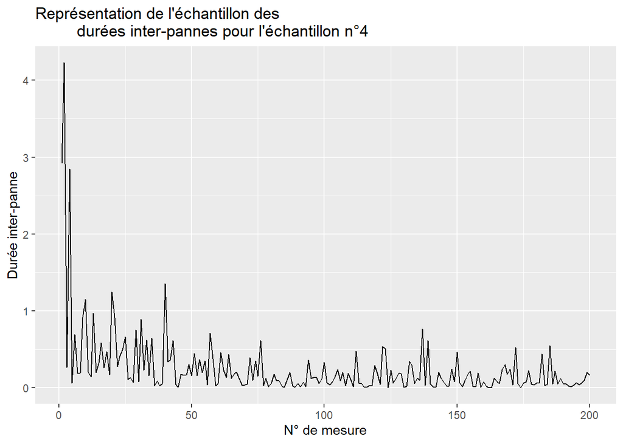

```r
ggplot() +
    geom_line(aes(x = 1:200, y = df[,"xi_sys4"])) +
    labs(x = "N° de mesure",
         y = "Durée inter-panne",
         title = "Représentation de l'échantillon des
         durées inter-pannes pour l'échantillon n°4")
```

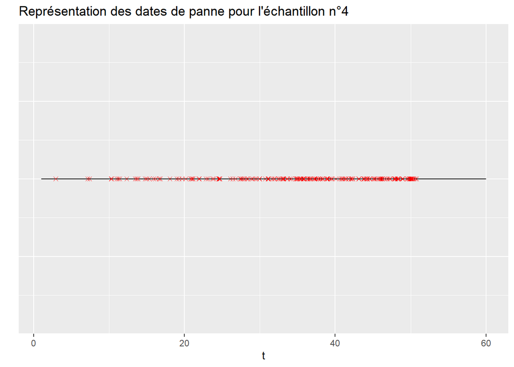

```r
ggplot() +
    geom_line(aes(x = 1:60, y = 1)) +
    geom_point(aes(x = df[,"ti_sys4"], y = 1)
               , color = "red",
               shape = 4) +
    labs(x = "t",
         y = "",
         title = "Représentation des dates de panne pour l'échantillon n°4") +
    guides(y = "none")
```

Il semble presque *évident* que ces données sont issues d’une loi avec tendance.

#### Tendance

Pour observer la tendance on peut utiliser le test de Laplace.

```r
compute_laplace_stat(df[,"ti_sys4"])
```

```
## [1] 9.690126
```

On peut préciser avec le test de place le type de tendance :

```r
compute_laplace_stat(df[,"ti_sys4"]) < qnorm(p = 0.05, mean = 0, sd = 1)
```

```
## [1] FALSE
```

```r
compute_laplace_stat(df[,"ti_sys4"]) > qnorm(p = 1-0.05, mean = 0, sd = 1)
```

```
## [1] TRUE
```

On est donc dans un système avec décroissance de fiabilité car la statistique de test $U$ est plus grande que le quantile de niveau $1-0.05=0.95$.

#### Adéquation à la loi de Weibull avec maintenance minimale

Dans le cas d’une tendance de fiabilité décroissante on peut d’abord tester une l’adéquation à une loi de Weibull avec maintenance minimale.

On appelle ce processus un processus de poisson non homogène (PPNH) ou *power law process (PLP)*.

Dans ce cas on parle de **loi de gamma-Weibull**.

Graphiquement on va regarder l’adéquation du nuage de point suivant :

$$\left( ln(t_i), ln(i) \right)$$

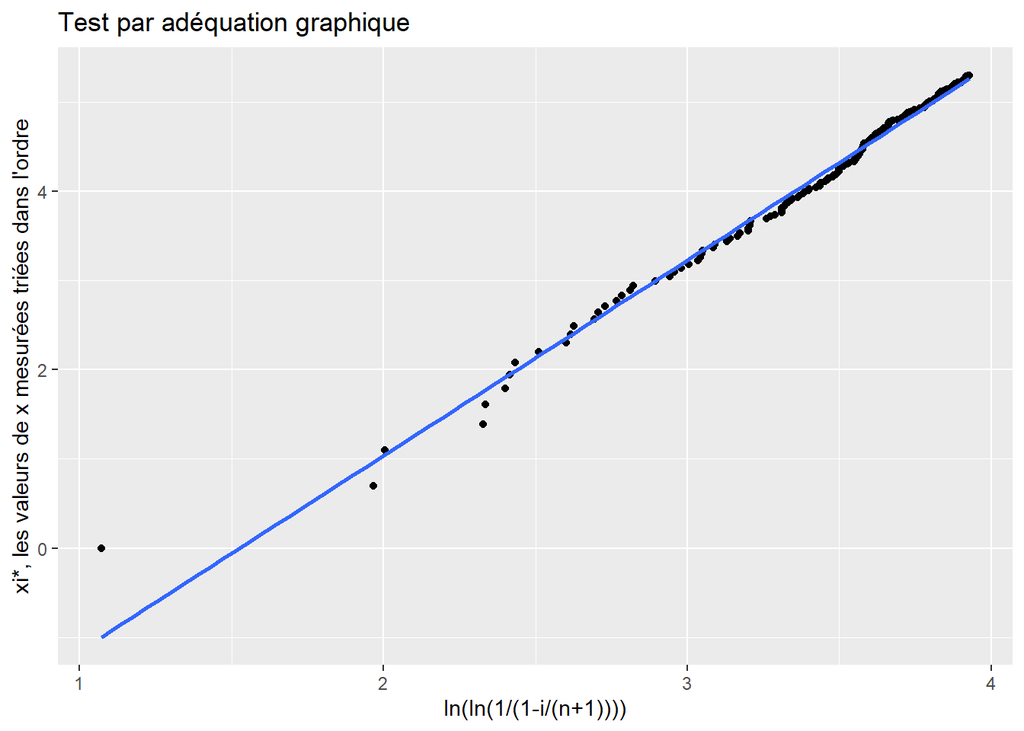

```r
nuage4 = tibble(log(df[,"ti_sys4"]),log(1:200))
colnames(nuage4) <- c('x','formula')

ggplot() +
    geom_point(aes(x = nuage4$`x`,y = nuage4$formula)) +
    geom_smooth(aes(x = nuage4$`x`,y = nuage4$formula),
                se = FALSE,
                method = lm) +
    labs(y = "xi*, les valeurs de x mesurées triées dans l'ordre",
         x = "ln(ln(1/(1-i/(n+1))))",
         title = "Test par adéquation graphique")
```

L’adéquation graphique est plutôt bonne. On vérifie avec la fonction `lm` :

```r
lm(nuage4$formula~nuage4$x) %>% summary()
```

```
##
## Call:
## lm(formula = nuage4$formula ~ nuage4$x)
##
## Residuals:
##      Min       1Q   Median       3Q      Max
## -0.37061 -0.06391  0.02346  0.04567  0.99743
##
## Coefficients:
##             Estimate Std. Error t value Pr(>|t|)
## (Intercept) -3.34278    0.05749  -58.14   <2e-16 ***
## nuage4$x     2.18977    0.01631  134.23   <2e-16 ***
## ---
## Signif. codes:  0 '***' 0.001 '**' 0.01 '*' 0.05 '.' 0.1 ' ' 1
##
## Residual standard error: 0.09976 on 198 degrees of freedom
## Multiple R-squared:  0.9891, Adjusted R-squared:  0.9891
## F-statistic: 1.802e+04 on 1 and 198 DF,  p-value: < 2.2e-16
```

On a une faible $p_{value}$ et un $R^2=0.9891$. Le modèle choisit semble pertinent.

#### Estimation des paramètres

On a donc :

$$\hat{\beta}_{gph} = \mbox{Pente de la droite} \\
\mbox{OaO} = ln(\alpha) \\
\alpha = exp(OaO)$$

```r
beta = 2.18977
alpha = exp(-3.34278)
estim_param_sys4_gph = list(beta = beta, alpha = alpha)
print(estim_param_sys4_gph)
```

```
## $beta
## [1] 2.18977
##
## $alpha
## [1] 0.03533858
```

On peut aussi utiliser l’estimateur du maximum de vraisemblance.

On a :

$$\hat{\alpha} = \frac{n}{t_{n}^{\hat{\beta}}} \space ;
\space \hat{\beta} = \frac{n}{\sum_{i=1}^{n} ln \left( \frac{t_n}{t_i}
\right)}$$

```r
beta = n/sum(log(df[n,"ti_sys4"]/df[,"ti_sys4"]))
alpha = n/(df[n,"ti_sys4"]^beta)
estim_param_sys4_mv = list(
  alpha = alpha,
  beta = beta
)
estim_param_sys4_mv
```

```
## $alpha
## [1] 0.02145103
##
## $beta
## [1] 2.327401
```

Nos deux approximations sont assez proches mais avec une loi comme la loi de Weibull, la moindre variation du paramètre (notamment pour $\beta$) peut avoir une incidence certaine sur les performances dur modèle choisit.

On peut calculer les $MTTF$ selon les deux modèles trouvés :